# Baseball Data Analysis

## Introduction

In 1994, Sean Lahman created a database which contains the pitching, hitting, and fielding statistics for Major League Baseball. Today his database contains baseball statistics from 1871 through 2014, and has expanded to include other information, such as awards earned, Hall of Fame players, player salaries, and which colleges players attended.

With such comprehensive information readily available, many questions can be asked and answered by analyzing this data. I have posed one question which can be answered with this data:

**Question**: Do left-handed pitchers strike out batters more often than right-handed pitchers? Is there a relationship between strikeouts and number of games played?

## Data Wrangling

To explore this question, we will need to look at two data sets that Sean Lahman created: player information and pitching statistics.

```python
#import packages and functions

import csv
from datetime import datetime
import numpy as np
import pandas as pd
import scipy
from IPython.display import display
from matplotlib import pyplot as plt
import seaborn as sns
%matplotlib inline
```

```python
# identify file locations

player_file = './baseballdatabank-2017.1/Master.csv'
pitching_file = './baseballdatabank-2017.1/Pitching.csv'
```

```python
# load csv files with pandas
players = pd.read_csv(player_file)
pitching = pd.read_csv(pitching_file)
```

```python
players.head()
```

|  | playerID | birthYear | birthMonth | birthDay | birthCountry | birthState | birthCity | deathYear | deathMonth | deathDay | ... | nameLast | nameGiven | weight | height | bats | throws | debut | finalGame | retroID | bbrefID |
| --- | --- | --- | --- | --- | --- | --- | --- | --- | --- | --- | --- | --- | --- | --- | --- | --- | --- | --- | --- | --- | --- |
| 0 | aardsda01 | 1981.0 | 12.0 | 27.0 | USA | CO | Denver | NaN | NaN | NaN | ... | Aardsma | David Allan | 215.0 | 75.0 | R | R | 2004-04-06 | 2015-08-23 | aardd001 | aardsda01 |
| 1 | aaronha01 | 1934.0 | 2.0 | 5.0 | USA | AL | Mobile | NaN | NaN | NaN | ... | Aaron | Henry Louis | 180.0 | 72.0 | R | R | 1954-04-13 | 1976-10-03 | aaroh101 | aaronha01 |
| 2 | aaronto01 | 1939.0 | 8.0 | 5.0 | USA | AL | Mobile | 1984.0 | 8.0 | 16.0 | ... | Aaron | Tommie Lee | 190.0 | 75.0 | R | R | 1962-04-10 | 1971-09-26 | aarot101 | aaronto01 |
| 3 | aasedo01 | 1954.0 | 9.0 | 8.0 | USA | CA | Orange | NaN | NaN | NaN | ... | Aase | Donald William | 190.0 | 75.0 | R | R | 1977-07-26 | 1990-10-03 | aased001 | aasedo01 |
| 4 | abadan01 | 1972.0 | 8.0 | 25.0 | USA | FL | Palm Beach | NaN | NaN | NaN | ... | Abad | Fausto Andres | 184.0 | 73.0 | L | L | 2001-09-10 | 2006-04-13 | abada001 | abadan01 |

5 rows × 24 columns

```python
pitching.head()
```

|  | playerID | yearID | stint | teamID | lgID | W | L | G | GS | CG | ... | IBB | WP | HBP | BK | BFP | GF | R | SH | SF | GIDP |
| --- | --- | --- | --- | --- | --- | --- | --- | --- | --- | --- | --- | --- | --- | --- | --- | --- | --- | --- | --- | --- | --- |
| 0 | bechtge01 | 1871 | 1 | PH1 | NaN | 1 | 2 | 3 | 3 | 2 | ... | NaN | NaN | NaN | 0 | NaN | NaN | 42 | NaN | NaN | NaN |
| 1 | brainas01 | 1871 | 1 | WS3 | NaN | 12 | 15 | 30 | 30 | 30 | ... | NaN | NaN | NaN | 0 | NaN | NaN | 292 | NaN | NaN | NaN |
| 2 | fergubo01 | 1871 | 1 | NY2 | NaN | 0 | 0 | 1 | 0 | 0 | ... | NaN | NaN | NaN | 0 | NaN | NaN | 9 | NaN | NaN | NaN |
| 3 | fishech01 | 1871 | 1 | RC1 | NaN | 4 | 16 | 24 | 24 | 22 | ... | NaN | NaN | NaN | 0 | NaN | NaN | 257 | NaN | NaN | NaN |
| 4 | fleetfr01 | 1871 | 1 | NY2 | NaN | 0 | 1 | 1 | 1 | 1 | ... | NaN | NaN | NaN | 0 | NaN | NaN | 21 | NaN | NaN | NaN |

5 rows × 30 columns

Both dataframes have a lot of information which are not relevant to the questions, so the unnecessary column information will be removed.

```python
# slicing the players and pitching table to only include relevant columns

# player information will be player name and which hand they throw with
players = players.loc[:,('playerID', 'throws')]
# pitching information will be the player name, number of games played, number of outs played, and number of strike-outs thrown.
pitching = pitching.loc[:,('playerID', 'G', 'GS', 'IPouts', 'SO')]
```

Because the pitching information is per player per year, we want to combine a players lifetime statistics into a single value.

```python
# Grouping by playerID to get the combined statistics for each player.
pitching_lt = pitching.groupby('playerID', as_index=False).sum()
pitching_lt.head()
```

|  | playerID | G | GS | IPouts | SO |
| --- | --- | --- | --- | --- | --- |
| 0 | aardsda01 | 331 | 0 | 1011 | 340 |
| 1 | aasedo01 | 448 | 91 | 3328 | 641 |
| 2 | abadfe01 | 315 | 6 | 822 | 234 |
| 3 | abbeybe01 | 79 | 66 | 1704 | 161 |
| 4 | abbeych01 | 1 | 0 | 6 | 0 |

Since the players dataframe has information on all players positions and not just pitchers, both tables will be merged together so only pitchers statistics will be shown.

```python
# merge pitcher and player information
pitcher_stats = pitching_lt.merge(players, on='playerID', how='inner')
```

## Exploratory Data Analysis

Now that the data has been cleaned up and refined to show the exact data we want to utilize, lets take a look at some basic statistics between the two groups of pitchers.

```python
pitcher_stats[pitcher_stats['throws']=='R'].describe()
```

|  | G | GS | IPouts | SO |
| --- | --- | --- | --- | --- |
| count | 6603.000000 | 6603.000000 | 6603.000000 | 6603.000000 |
| mean | 115.600182 | 46.807966 | 1266.613812 | 228.426321 |
| std | 162.425761 | 93.837855 | 2150.555608 | 405.557035 |
| min | 1.000000 | 0.000000 | 0.000000 | 0.000000 |
| 25% | 7.000000 | 0.000000 | 52.000000 | 8.000000 |
| 50% | 40.000000 | 4.000000 | 318.000000 | 54.000000 |
| 75% | 164.000000 | 43.500000 | 1523.000000 | 268.500000 |
| max | 1115.000000 | 815.000000 | 22064.000000 | 5714.000000 |

```python
pitcher_stats[pitcher_stats['throws']=='L'].describe()
```

|  | G | GS | IPouts | SO |
| --- | --- | --- | --- | --- |
| count | 2477.000000 | 2477.000000 | 2477.000000 | 2477.000000 |
| mean | 120.565604 | 46.420266 | 1205.750505 | 232.105773 |
| std | 172.605439 | 94.396060 | 2076.914208 | 421.019299 |
| min | 1.000000 | 0.000000 | 0.000000 | 0.000000 |
| 25% | 8.000000 | 0.000000 | 51.000000 | 8.000000 |
| 50% | 40.000000 | 4.000000 | 279.000000 | 49.000000 |
| 75% | 165.000000 | 42.000000 | 1428.000000 | 261.000000 |
| max | 1252.000000 | 709.000000 | 15731.000000 | 4875.000000 |

This information is a good start, however there are still a few issues with the data:

1.) It only reflects the raw numbers. Pitchers with longer careers will have higher numbers. Since we are comparing the **performance** between left-handed and right-handed pitchers, the number of strikeouts is not as important as the number of strikeouts per inning outs.  
2.) G is the number of games played and GS is the number of games started. The descriptive statistics shows that at least 25% of baseball pitchers have played in less than 8 games, and didn't start in any!  
3.) There is the possibility of missing statistics from players. This will cause an issue with data analysis if a player is not included in every calculation.  
4.) There are players who have an 'IPout' value of 0. Since our analysis will look at comparing the strikeouts per inning outs, pitchers should have played for at least one inning out.

First we will identify the non-values from the data set.

```python
pitcher_stats.isnull().sum()
```

```
playerID      0
G             0
GS            0
IPouts        0
SO            0
throws      221
dtype: int64
```

```python
# remove players whose throwing arm is unknown
pitcher_stats.dropna()
pitcher_stats.isnull().sum()
```

```
playerID      0
G             0
GS            0
IPouts        0
SO            0
throws      221
dtype: int64
```

Next we will identify the number of players who have participated in 0 inning outs and remove them from the data set.

```python
len(pitcher_stats[pitcher_stats['IPouts']==0])
```

```
28
```

```python
#remove pitchers who have played 0 IPouts from the dataset
pitcher_stats = pitcher_stats.drop(pitcher_stats[pitcher_stats['IPouts']==0].index)
pitcher_stats.describe()
```

|  | G | GS | IPouts | SO |
| --- | --- | --- | --- | --- |
| count | 9274.000000 | 9274.000000 | 9274.000000 | 9274.000000 |
| mean | 114.812810 | 45.987600 | 1230.844619 | 225.449429 |
| std | 164.312192 | 93.310587 | 2118.284539 | 406.948801 |
| min | 1.000000 | 0.000000 | 1.000000 | 0.000000 |
| 25% | 7.000000 | 0.000000 | 51.000000 | 7.000000 |
| 50% | 38.000000 | 4.000000 | 293.000000 | 50.000000 |
| 75% | 161.000000 | 42.000000 | 1451.750000 | 259.000000 |
| max | 1252.000000 | 815.000000 | 22064.000000 | 5714.000000 |

Now that we have eliminated the 0 values for IP outs, we will address the issue with the raw numbers. Below, the strikeouts per inning outs will be added to the table.

```python
pitcher_stats['SO_per_IO'] = pitcher_stats['SO'] / pitcher_stats['IPouts']
```

```python
pitcher_stats.describe()
```

|  | G | GS | IPouts | SO | SO_per_IO |
| --- | --- | --- | --- | --- | --- |
| count | 9274.000000 | 9274.000000 | 9274.000000 | 9274.000000 | 9274.000000 |
| mean | 114.812810 | 45.987600 | 1230.844619 | 225.449429 | 0.176853 |
| std | 164.312192 | 93.310587 | 2118.284539 | 406.948801 | 0.100502 |
| min | 1.000000 | 0.000000 | 1.000000 | 0.000000 | 0.000000 |
| 25% | 7.000000 | 0.000000 | 51.000000 | 7.000000 | 0.111111 |
| 50% | 38.000000 | 4.000000 | 293.000000 | 50.000000 | 0.169954 |
| 75% | 161.000000 | 42.000000 | 1451.750000 | 259.000000 | 0.235940 |
| max | 1252.000000 | 815.000000 | 22064.000000 | 5714.000000 | 1.000000 |

Now lets standardize the "Strike Outs per Inning Outs" values into a Z-score for comparison.

```python
#create a function to standardize values
def standardize (df, column):
    df[column+'_std'] = (df[column] - df[column].mean()) / np.std(df[column])
    return df
```

```python
pitcher_stats = standardize(pitcher_stats, 'SO_per_IO')
pitcher_stats.head(5)
```

|  | playerID | G | GS | IPouts | SO | throws | SO_per_IO | SO_per_IO_std |
| --- | --- | --- | --- | --- | --- | --- | --- | --- |
| 0 | aardsda01 | 331 | 0 | 1011 | 340 | R | 0.336301 | 1.586598 |
| 1 | aasedo01 | 448 | 91 | 3328 | 641 | R | 0.192608 | 0.156769 |
| 2 | abadfe01 | 315 | 6 | 822 | 234 | L | 0.284672 | 1.072856 |
| 3 | abbeybe01 | 79 | 66 | 1704 | 161 | R | 0.094484 | -0.819631 |
| 4 | abbeych01 | 1 | 0 | 6 | 0 | L | 0.000000 | -1.759801 |

Now that we have standardized the pitchers efficiency as 'SO_per_IO_std', we can compare the performance between left handed and right handed pitchers.

```python
pitcher_stats[pitcher_stats['throws']=='L'].describe()
```

|  | G | GS | IPouts | SO | SO_per_IO | SO_per_IO_std |
| --- | --- | --- | --- | --- | --- | --- |
| count | 2472.000000 | 2472.000000 | 2472.000000 | 2472.000000 | 2472.000000 | 2472.000000 |
| mean | 120.807039 | 46.513350 | 1208.189320 | 232.575243 | 0.186547 | 0.096459 |
| std | 172.696360 | 94.468788 | 2078.305386 | 421.315432 | 0.100882 | 1.003834 |
| min | 1.000000 | 0.000000 | 1.000000 | 0.000000 | 0.000000 | -1.759801 |
| 25% | 8.000000 | 0.000000 | 52.000000 | 8.000000 | 0.122449 | -0.541358 |
| 50% | 40.000000 | 4.000000 | 281.500000 | 50.000000 | 0.182406 | 0.055255 |
| 75% | 168.000000 | 42.000000 | 1430.000000 | 262.750000 | 0.244221 | 0.670347 |
| max | 1252.000000 | 709.000000 | 15731.000000 | 4875.000000 | 1.000000 | 8.190813 |

```python
pitcher_stats[pitcher_stats['throws']=='R'].describe()
```

|  | G | GS | IPouts | SO | SO_per_IO | SO_per_IO_std |
| --- | --- | --- | --- | --- | --- | --- |
| count | 6583.000000 | 6583.000000 | 6583.000000 | 6583.000000 | 6583.000000 | 6583.000000 |
| mean | 115.948352 | 46.949415 | 1270.461947 | 229.120310 | 0.175524 | -0.013227 |
| std | 162.549269 | 93.945155 | 2152.685048 | 405.976913 | 0.099534 | 0.990427 |
| min | 1.000000 | 0.000000 | 1.000000 | 0.000000 | 0.000000 | -1.759801 |
| 25% | 7.000000 | 0.000000 | 54.000000 | 8.000000 | 0.109890 | -0.666327 |
| 50% | 41.000000 | 4.000000 | 324.000000 | 54.000000 | 0.167273 | -0.095334 |
| 75% | 165.000000 | 44.000000 | 1530.000000 | 271.000000 | 0.233759 | 0.566246 |
| max | 1115.000000 | 815.000000 | 22064.000000 | 5714.000000 | 1.000000 | 8.190813 |

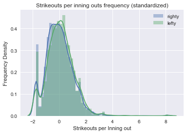

```python
righty = pitcher_stats[pitcher_stats['throws']=='R']
lefty = pitcher_stats[pitcher_stats['throws']=='L']

# creating a pandas series to assign a label to each axis
r_hist = pd.Series(righty['SO_per_IO_std'], name="Strikeouts per Inning out")
l_hist = pd.Series(lefty['SO_per_IO_std'], name="Strikeouts per Inning out")

# plot the data in seaborn
sns.distplot(r_hist, label = 'righty').set_ylabel('Frequency Density')
sns.distplot(l_hist, label = 'lefty').set_ylabel('Frequency Density')
sns.plt.title('Strikeouts per inning outs frequency (standardized)')
sns.plt.legend()
```

In the above histogram plot, the blue trendline represents right handed players, and the green trendline represents left handed players.

To address the second issue mentioned above, the number of games played per player will be standardized, and compared with the strikeout performance.

```python
# run games played through the standardize function
pitcher_stats = standardize(pitcher_stats, 'G')
pitcher_stats.head(5)
```

|  | playerID | G | GS | IPouts | SO | throws | SO_per_IO | SO_per_IO_std | G_std |
| --- | --- | --- | --- | --- | --- | --- | --- | --- | --- |
| 0 | aardsda01 | 331 | 0 | 1011 | 340 | R | 0.336301 | 1.586598 | 1.315781 |
| 1 | aasedo01 | 448 | 91 | 3328 | 641 | R | 0.192608 | 0.156769 | 2.027878 |
| 2 | abadfe01 | 315 | 6 | 822 | 234 | L | 0.284672 | 1.072856 | 1.218400 |
| 3 | abbeybe01 | 79 | 66 | 1704 | 161 | R | 0.094484 | -0.819631 | -0.217968 |
| 4 | abbeych01 | 1 | 0 | 6 | 0 | L | 0.000000 | -1.759801 | -0.692699 |

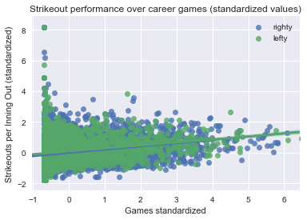

```python
scatter_x = pitcher_stats[pitcher_stats['throws'] == 'R']['G_std']
scatter_y = pitcher_stats[pitcher_stats['throws'] == 'R']['SO_per_IO_std']
r_scatter_x = pd.Series(scatter_x, name= "Games (standardized)")
r_scatter_y = pd.Series(scatter_y, name= "Strikeouts per Inning Out (standardized)")

r_scatter = sns.regplot(r_scatter_x,r_scatter_y, label='righty')

scatter_x = pitcher_stats[pitcher_stats['throws'] == 'L']['G_std']
scatter_y = pitcher_stats[pitcher_stats['throws'] == 'L']['SO_per_IO_std']
l_scatter_x = pd.Series(scatter_x, name= "Games standardized")
l_scatter_y = pd.Series(scatter_y, name= "Strikeouts per Inning Out (standardized)")

l_scatter = sns.regplot(l_scatter_x,l_scatter_y, label='lefty')
sns.plt.title('Strikeout performance over career games (standardized values)')
sns.plt.legend()
```

The blue dots represents right handed players, and the green dots represent left handed players. The trend lines are very close and both slope upward. To check for a correlation between the two, Pearsons R will be calculated for both sets of data.

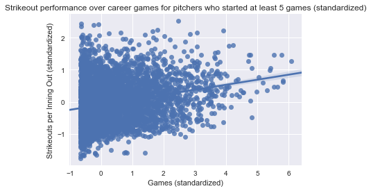

```python
scatter_x2 = pitcher_stats[pitcher_stats['GS'] >= 5]['G_std']
scatter_y2 = pitcher_stats[pitcher_stats['GS'] >= 5]['SO_per_IO_std']
b_scatter_x2 = pd.Series(scatter_x2, name= "Games (standardized)")
b_scatter_y2 = pd.Series(scatter_y2, name= "Strikeouts per Inning Out (standardized)")
sns.regplot(b_scatter_x2,b_scatter_y2)
sns.plt.title('Strikeout performance over career games for pitchers who started at least 5 games (standardized)')
```

## Conclusions and Findings

In the introduction, two questions were asked regarding Sean Lahman's data:

> Do left-handed pitchers strike out batters more often than right-handed pitchers? Is there a relationship between strikeouts and number of games played?

To explore these questions, player information and pitching statistics were processed and refined to produce the following information: player name, games played, games started, inning outs played, strikeouts, and throwing hand. There was certainly some surprising information from the basic statistics of these players.

```python
pitcher_stats.describe()
```

|  | G | GS | IPouts | SO | SO_per_IO | SO_per_IO_std | G_std |
| --- | --- | --- | --- | --- | --- | --- | --- |
| count | 9274.000000 | 9274.000000 | 9274.000000 | 9274.000000 | 9274.000000 | 9.274000e+03 | 9.274000e+03 |
| mean | 114.812810 | 45.987600 | 1230.844619 | 225.449429 | 0.176853 | 1.321015e-15 | 1.854841e-16 |
| std | 164.312192 | 93.310587 | 2118.284539 | 406.948801 | 0.100502 | 1.000054e+00 | 1.000054e+00 |
| min | 1.000000 | 0.000000 | 1.000000 | 0.000000 | 0.000000 | -1.759801e+00 | -6.926993e-01 |
| 25% | 7.000000 | 0.000000 | 51.000000 | 7.000000 | 0.111111 | -6.541770e-01 | -6.561815e-01 |
| 50% | 38.000000 | 4.000000 | 293.000000 | 50.000000 | 0.169954 | -6.865409e-02 | -4.675061e-01 |
| 75% | 161.000000 | 42.000000 | 1451.750000 | 259.000000 | 0.235940 | 5.879451e-01 | 2.811093e-01 |
| max | 1252.000000 | 815.000000 | 22064.000000 | 5714.000000 | 1.000000 | 8.190813e+00 | 6.921267e+00 |

The data has been plotted below, seperated by throwing hand.

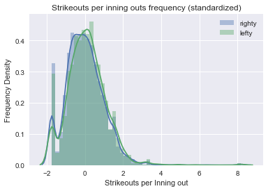

```python
sns.distplot(r_hist, label = 'righty').set_ylabel('Frequency Density')
sns.distplot(l_hist, label = 'lefty').set_ylabel('Frequency Density')
sns.plt.title('Strikeouts per inning outs frequency (standardized)')
sns.plt.legend()
```

This data shows a similar performance between left handed and right handed players in terms of strikeouts per inning. It does appear the right handed players perform slightly worse than the left handed players, as the blue trendline is higher than the green for z-scores below zero, and lower for scores above zero. This may indicate a slight advantage for left handed pitchers, however more analysis is needed to reach a conclusion. Lets look at the statistics for each group:

```python
# right handed pitchers
r_hist.describe()
```

```
count    6583.000000
mean       -0.013227
std         0.990427
min        -1.759801
25%        -0.666327
50%        -0.095334
75%         0.566246
max         8.190813
Name: Strikeouts per Inning out, dtype: float64
```

```python
# left handed pitchers
l_hist.describe()
```

```
count    2472.000000
mean        0.096459
std         1.003834
min        -1.759801
25%        -0.541358
50%         0.055255
75%         0.670347
max         8.190813
Name: Strikeouts per Inning out, dtype: float64
```

The above information summaries compares the left handed with the right handed players. There are a few statistics to note:

1.) The average right handed pitcher is slightly below the overall average. This is represented with the mean value of -.013227. The average left handed pitcher is slightly above the overall average, with a mean value of .096459. This means that the average left handed player has a performance of .1 standard deviations greater than that of a right handed player.  
2.) When looking at the interquartile range, or the middle 50% of players in both groups, it appears the left handed pitchers also performed better. The right handed pitchers fall between -.666 and +.566 standard deviations. The left handed pitchers fell between -.541 and + .670 standard deviations. These statistics indicate that middle group of left handed pitchers perform .104 to .125 better than right handed pitchers.

While this may indicate that left handed pitchers have a better strikeout performance than right handed pitchers, the advantage is very small, by about .1 standard deviations. A T-Test should be performed to see if left handed pitchers do in fact have an advantage over right handed pitchers:

```python
scipy.stats.ttest_ind(l_hist, r_hist)
```

```
Ttest_indResult(statistic=4.6774707302424234, pvalue=2.9464292134120763e-06)
```

With T-statistic of 4.677 and a P value of .00000294, this is below the .01 threshold for significance. This indicates that left handed pitchers do have an advantage over right handed pitchers, however this does not necessarily mean that left handed pitchers are better at striking out batters. There are other factors which need to be considered, such as which hand the batters hit with.

To explore the strikeout performance based on how many games a pitcher has played in, the scatterplot below shows the comparison between left handed and right handed pitchers. Right handed pitchers are in blue, and left handed pitchers are in green.

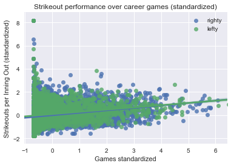

```python
r_scatter = sns.regplot(r_scatter_x,r_scatter_y, label='righty')
l_scatter = sns.regplot(l_scatter_x,l_scatter_y, label='lefty')
sns.plt.title('Strikeout performance over career games (standardized)')
sns.plt.legend()
```

The scatter plot above shows several interesting things. The trendlines for both left and right handed players are almost identical, indicating that the throwing hand of a pitcher does not appear to be related. The trendline slopes upward, which shows that the more games a player has pitched, the more strikeouts per inning out thrown. This makes sense, as pitchers who perform well are going to be used in more games. However this doesn't necessarily mean this is the direct cause of the relationship shown. Lets look at the Pearson's R coefficient to determine if these two statistics are indeed correlated.

```python
scipy.stats.pearsonr(l_scatter_x, l_scatter_y)
```

```
(0.20195233549731439, 3.6527110778437337e-24)
```

```python
scipy.stats.pearsonr(r_scatter_x, r_scatter_y)
```

```
(0.21145648103518103, 1.9741877416264213e-67)
```

The Pearson's R coefficient for both sets is roughly .2 with a very small p-value. This indicates a weak positive correlation between the number of games played and the strikeout performance of a pitcher. There are many other factors which can affect the career length of a player, such as injury or the number of hits or runs, so the career of a pitcher is not necessarily reliant upon strikeout performance.

One point to note is that there are a few players with exceptional strikeout performance, but have only played in few games. This is shown by the vertical row of dots on the left side. These players could have been exceptional players that got injured early in their career, or pitching specialists that only pitch to specific types of batters (such as the Lefty One-Out GuY aka: LOOGY) and are seldomly used.

Below is a scatter plot that reflects pitchers who have started in at least 5 games:

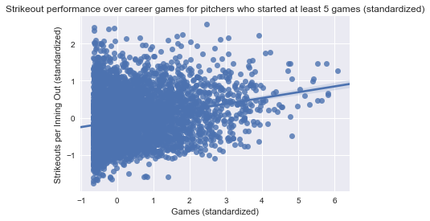

```python
sns.regplot(b_scatter_x2,b_scatter_y2)
sns.plt.title('Strikeout performance over career games for pitchers who started at least 5 games (standardized)')
```

This scatter plot is much more condensed and shows players who participated in more games. The strikeouts per inning out isn't as extreme on the lower games side, as players who have only played in few games are outliers. Lets look at the Pearson's R coefficient for this group of players to see if there is a stronger correlatiton:

```python
scipy.stats.pearsonr(b_scatter_x2, b_scatter_y2)
```

```
(0.24522202239874233, 4.0716354108825137e-63)
```

The correlation between strikeouts and games played did increase among pitchers who have started at least 5 games, however this value still represents a weak correlation between the two statistics.

Additionally, this data analysis has shown that the more games a pitcher has played in, the better their strikeout performance is. While these two data points certainly look correlated, there may be other factors that impact the strikeout performance as well as the number of games played. Injuries can reduce the amount of games played, but also the career length of a pitcher may also be impacted by the number of hits, walks, home runs, and win-loss ratio as well.